# Unit1-6_Assign2_Internet Privacy

Kyu Cho

Saturday, June 13, 2015

# Introduction

Internet privacy has gained widespread attention in recent years. To measure the degree to which people are concerned about hot-button issues like Internet privacy, social scientists conduct polls in which they interview a large number of people about the topic. In this assignment, we will analyze data from a July 2013 Pew Internet and American Life Project poll on Internet anonymity and privacy, which involved interviews across the United States. While the full polling data can be found here, we will use a more limited version of the results, available in AnonymityPoll.csv. The dataset has the following fields (all Internet use-related fields were only collected from interviewees who either use the Internet or have a smartphone):

# Variables

- Internet.Use: A binary variable indicating if the interviewee uses the Internet, at least occasionally (equals 1 if the interviewee uses the Internet, and equals 0 if the interviewee does not use the Internet).
- Smartphone: A binary variable indicating if the interviewee has a smartphone (equals 1 if they do have a smartphone, and equals 0 if they don’t have a smartphone).
- Sex: Male or Female.
- Age: Age in years.
- State: State of residence of the interviewee.
- Region: Census region of the interviewee (Midwest, Northeast, South, or West).
- Conservativeness: Self-described level of conservativeness of interviewee, from 1 (very liberal) to 5 (very conservative). Info.On.Internet: Number of the following items this interviewee believes to be available on the Internet for others to see: (1) Their email address; (2) Their home address; (3) Their home phone - number; (4) Their cell phone number; (5) The employer/company they work for; (6) Their political party or political affiliation; (7) Things they’ve written that have their name on it; (8) A photo of them; (9) A video of them; (10) Which groups or organizations they belong to; and (11) Their birth date.
- Worry.About.Info: A binary variable indicating if the interviewee worries about how much information is available about them on the Internet (equals 1 if they worry, and equals 0 if they don’t worry).
- Privacy.Importance: A score from 0 (privacy is not too important) to 100 (privacy is very important), which combines the degree to which they find privacy important in the following: (1) The websites they browse; (2) Knowledge of the place they are located when they use the Internet; (3) The content and files they download; (4) The times of day they are online; (5) The applications or programs they use; (6) The searches they perform; (7) The content of their email; (8) The people they exchange email with; and (9) The content of their online chats or hangouts with others.
- Anonymity.Possible: A binary variable indicating if the interviewee thinks it’s possible to use the Internet anonymously, meaning in such a way that online activities can’t be traced back to them (equals 1 if he/she believes you can, and equals 0 if he/she believes you can’t).
- Tried.Masking.Identity: A binary variable indicating if the interviewee has ever tried to mask his/her identity when using the Internet (equals 1 if he/she has tried to mask his/her identity, and equals 0 if he/she has not tried to mask his/her identity).
- Privacy.Laws.Effective: A binary variable indicating if the interviewee believes United States law provides reasonable privacy protection for Internet users (equals 1 if he/she believes it does, and equals 0 if he/she believes it doesn’t).

# Loading Data and Summarizing the Dataset

```r
# Set the directory at where the data is located
setwd("D:/Google Drive/College/4-The Analytics Edge/data/")

# Read the Data
poll  <- read.csv("AnonymityPoll.csv")
str(poll)
```

```
## 'data.frame':    1002 obs. of  13 variables:
##  $ Internet.Use          : int  1 1 0 1 0 1 1 0 0 1 ...
##  $ Smartphone            : int  0 0 1 0 NA 1 0 0 NA 0 ...
##  $ Sex                   : Factor w/ 2 levels "Female","Male": 2 2 1 2 1 2 1 1 2 1 ...
##  $ Age                   : int  62 45 70 70 80 49 52 76 75 76 ...
##  $ State                 : Factor w/ 49 levels "Alabama","Arizona",..: 20 39 29 10 10 41 21 31 32 32 ...
##  $ Region                : Factor w/ 4 levels "Midwest","Northeast",..: 2 3 2 3 3 3 1 2 3 3 ...
##  $ Conservativeness      : int  4 1 4 4 4 4 3 3 4 4 ...
##  $ Info.On.Internet      : int  0 1 0 3 NA 6 3 NA NA 0 ...
##  $ Worry.About.Info      : int  1 0 0 1 NA 0 1 NA NA 0 ...
##  $ Privacy.Importance    : num  100 0 NA 88.9 NA ...
##  $ Anonymity.Possible    : int  0 1 0 1 NA 1 0 NA NA 1 ...
##  $ Tried.Masking.Identity: int  0 0 0 0 NA 1 0 NA NA 0 ...
##  $ Privacy.Laws.Effective: int  0 1 NA 0 NA 0 1 NA 0 1 ...
```

How many interviewees responded that they use a smartphone? How many interviewees responded that they don’t use a smartphone? How many interviewees did not respond to the question, resulting in a missing value, or NA, in the summary() output?

```r
table(poll$Smartphone)
```

```
##
##   0   1
## 472 487
```

```r
summary(poll)
```

```
##   Internet.Use      Smartphone         Sex           Age
##  Min.   :0.0000   Min.   :0.0000   Female:505   Min.   :18.00
##  1st Qu.:1.0000   1st Qu.:0.0000   Male  :497   1st Qu.:37.00
##  Median :1.0000   Median :1.0000                Median :55.00
##  Mean   :0.7742   Mean   :0.5078                Mean   :52.37
##  3rd Qu.:1.0000   3rd Qu.:1.0000                3rd Qu.:66.00
##  Max.   :1.0000   Max.   :1.0000                Max.   :96.00
##  NA's   :1        NA's   :43                    NA's   :27
##           State           Region    Conservativeness Info.On.Internet
##  California  :103   Midwest  :239   Min.   :1.000    Min.   : 0.000
##  Texas       : 72   Northeast:166   1st Qu.:3.000    1st Qu.: 2.000
##  New York    : 60   South    :359   Median :3.000    Median : 4.000
##  Pennsylvania: 45   West     :238   Mean   :3.277    Mean   : 3.795
##  Florida     : 42                   3rd Qu.:4.000    3rd Qu.: 6.000
##  Ohio        : 38                   Max.   :5.000    Max.   :11.000
##  (Other)     :642                   NA's   :62       NA's   :210
##  Worry.About.Info Privacy.Importance Anonymity.Possible
##  Min.   :0.0000   Min.   :  0.00     Min.   :0.0000
##  1st Qu.:0.0000   1st Qu.: 41.43     1st Qu.:0.0000
##  Median :0.0000   Median : 68.75     Median :0.0000
##  Mean   :0.4886   Mean   : 62.85     Mean   :0.3692
##  3rd Qu.:1.0000   3rd Qu.: 88.89     3rd Qu.:1.0000
##  Max.   :1.0000   Max.   :100.00     Max.   :1.0000
##  NA's   :212      NA's   :215        NA's   :249
##  Tried.Masking.Identity Privacy.Laws.Effective
##  Min.   :0.0000         Min.   :0.0000
##  1st Qu.:0.0000         1st Qu.:0.0000
##  Median :0.0000         Median :0.0000
##  Mean   :0.1633         Mean   :0.2617
##  3rd Qu.:0.0000         3rd Qu.:1.0000
##  Max.   :1.0000         Max.   :1.0000
##  NA's   :218            NA's   :108
```

Which of the following are states in the Midwest census region?

```r
MidwestInterviewees = subset(poll, Region=="Midwest")
tail(sort(table(MidwestInterviewees$State)))
```

```
##
## Wisconsin  Missouri   Indiana  Michigan  Illinois      Ohio
##        23        26        27        31        32        38
```

Which was the state in the South census region with the largest number of interviewees?

```r
SouthInterviewees = subset(poll, Region=="South")
tail(sort(table(SouthInterviewees$State)))
```

```
##
##       Kentucky       Virginia North Carolina        Georgia        Florida
##             25             31             32             34             42
##          Texas
##             72
```

# INTERNET AND SMARTPHONE USERS

How many interviewees reported not having used the Internet and not having used a smartphone?  
How many interviewees reported having used the Internet and having used a smartphone?  
How many interviewees reported having used the Internet but not having used a smartphone?  
How many interviewees reported having used a smartphone but not having used the Internet?

```r
table(poll$Internet.Use, poll$Smartphone)
```

```
##
##       0   1
##   0 186  17
##   1 285 470
```

How many interviewees have Smartphone or Internet?

```r
limited <- subset(poll, Smartphone == 1 | Internet.Use == 1)
summary(limited)
```

```
##   Internet.Use      Smartphone         Sex           Age
##  Min.   :0.0000   Min.   :0.0000   Female:392   Min.   :18.00
##  1st Qu.:1.0000   1st Qu.:0.0000   Male  :400   1st Qu.:33.00
##  Median :1.0000   Median :1.0000                Median :51.00
##  Mean   :0.9785   Mean   :0.6308                Mean   :48.57
##  3rd Qu.:1.0000   3rd Qu.:1.0000                3rd Qu.:62.00
##  Max.   :1.0000   Max.   :1.0000                Max.   :93.00
##                   NA's   :20                    NA's   :22
##             State           Region    Conservativeness Info.On.Internet
##  California    : 89   Midwest  :172   Min.   :1.000    Min.   : 0.000
##  Texas         : 57   Northeast:128   1st Qu.:3.000    1st Qu.: 2.000
##  New York      : 45   South    :288   Median :3.000    Median : 4.000
##  Pennsylvania  : 33   West     :204   Mean   :3.237    Mean   : 3.795
##  Florida       : 32                   3rd Qu.:4.000    3rd Qu.: 6.000
##  North Carolina: 28                   Max.   :5.000    Max.   :11.000
##  (Other)       :508                   NA's   :45
##  Worry.About.Info Privacy.Importance Anonymity.Possible
##  Min.   :0.0000   Min.   :  0.00     Min.   :0.0000
##  1st Qu.:0.0000   1st Qu.: 41.43     1st Qu.:0.0000
##  Median :0.0000   Median : 68.75     Median :0.0000
##  Mean   :0.4886   Mean   : 62.85     Mean   :0.3692
##  3rd Qu.:1.0000   3rd Qu.: 88.89     3rd Qu.:1.0000
##  Max.   :1.0000   Max.   :100.00     Max.   :1.0000
##  NA's   :2        NA's   :5          NA's   :39
##  Tried.Masking.Identity Privacy.Laws.Effective
##  Min.   :0.0000         Min.   :0.0000
##  1st Qu.:0.0000         1st Qu.:0.0000
##  Median :0.0000         Median :0.0000
##  Mean   :0.1633         Mean   :0.2559
##  3rd Qu.:0.0000         3rd Qu.:1.0000
##  Max.   :1.0000         Max.   :1.0000
##  NA's   :8              NA's   :65
```

# SUMMARIZING OPINIONS ABOUT INTERNET PRIVACY

What proportion of interviewees who answered the Worry.About.Info question worry about how much information is available about them on the Internet?

```r
sum(limited$Worry.About.Info==1, na.rm=T)/sum(limited$Worry.About.Info==1 | limited$Worry.About.Info==0, na.rm=T)
```

```
## [1] 0.4886076
```

What proportion of interviewees who answered the Anonymity.Possible question think it is possible to be completely anonymous on the Internet

```r
sum(limited$Anonymity.Possible == 1, na.rm=T)/sum(limited$Anonymity.Possible==1 | limited$Anonymity.Possible==0, na.rm=T)
```

```
## [1] 0.3691899
```

# RELATING DEMOGRAPHICS TO POLLING RESULTS

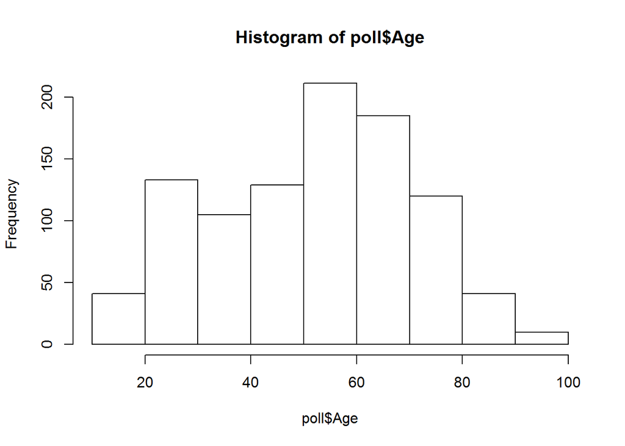

```r
hist(poll$Age)
```

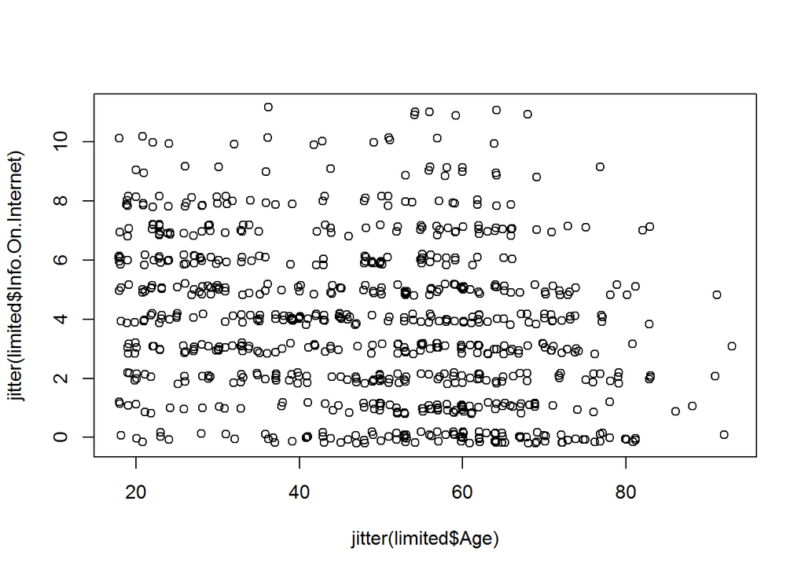

```r
# jitter() function addes notise to the value.
plot(jitter(limited$Age), jitter(limited$Info.On.Internet))
```

What is the average Info.On.Internet value for smartphone users?  
What is the average Info.On.Internet value for non-smartphone users?

```r
tapply(limited$Info.On.Internet, limited$Smartphone, mean)
```

```
##        0        1
## 2.922807 4.367556
```

What proportion of smartphone users who answered the Tried.Masking.Identity question have tried masking their identity when using the Internet?

What proportion of non-smartphone users who answered the Tried.Masking.Identity question have tried masking their identity when using the Internet?

```r
table(limited$Tried.Masking.Identity, limited$Smartphone)
```

```
##
##       0   1
##   0 248 390
##   1  33  93
```